# Homework 4

## Problem 4.30

#### The Model

The model for a pxp Latin Square experiment would look like :  
$y_{ijk} = \mu + \alpha_i + \tau_j + \beta_k + \epsilon_{ijk}$ for $i,j,k \in 1...p$ such that $\alpha_i$ is the $i^{th}$ row effect, $\tau_j$ is the $j^{th}$ treatment effect, $\beta_k$ is the $k^{th}$ column effect, and $\epsilon_{ijk}$ is that element’s error effect.

#### Sum of Squared Errors

We begin by looking at the sum of squared errors, which we will call $\Delta$. We know that $\Delta = \sum_{i = 1}^{p} \sum_{j = 1}^{p} \sum_{k = 1}^{p} (y_{ijk} - \hat{\mu} - \hat{\alpha_i} - \hat{\tau_j} - \hat{\beta_k})^2$

#### Partial Differentials

By setting $\frac{\delta\Delta}{\delta\hat{\mu}} = 0$, we replace $\frac{\delta\Delta}{\delta\hat{\mu}}$ with $(-2)\sum_{i = 1}^{p} \sum_{j = 1}^{p} \sum_{k = 1}^{p} (y_{ijk} - \hat{\mu} - \hat{\alpha_i} - \hat{\tau_j} - \hat{\beta_k})$  
And so $\sum_{i = 1}^{p} \sum_{j = 1}^{p} \sum_{k = 1}^{p} y_{ijk} = p^2\hat{\mu} + p\sum_{i=1}^p \hat{\alpha_i} + p\sum_{j=1}^p \hat{\tau_i} + p\sum_{k=1}^p \hat{\beta_k}$

Similarly $\frac{\delta\Delta}{\delta\hat{\alpha_i}} = 0$ yields:  
$\sum_{j = 1}^{p} \sum_{k = 1}^{p} y_{ijk} = p\hat{\mu} + p\hat{\alpha_i} + p\sum_{j=1}^p \hat{\tau_j} + p\sum_{k=1}^p \hat{\beta_k}$

With $\frac{\delta\Delta}{\delta\hat{\beta_k}} = 0$ giving us:  
$\sum_{i = 1}^{p} \sum_{j = 1}^{p} y_{ijk} = p\hat{\mu} + p\sum_{i=1}^p \hat{\alpha_i} + p\sum_{j=1}^p \hat{\tau_j} + p\hat{\beta_k}$

And $\frac{\delta\Delta}{\delta\hat{\tau_j}} = 0$ giving us:  
$\sum_{i = 1}^{p} \sum_{k = 1}^{p} y_{ijk} = p\hat{\mu} + p\sum_{i=1}^p \hat{\alpha_i} + p\hat{\tau_j} + p\sum_{k=1}^p \hat{\beta_k}$

#### Results

This yields $3p+1$ equations since there are p for the each of the rows, column, and treatments with one extra to solve for $\hat{\mu}$. There are also $3p+1$ unknowns. We also need to satisfy the condition that $\sum_{i=1}^p \hat{\alpha_i} = \sum_{j=1}^p \hat{\tau_j} = \sum_{k=1}^p \hat{\beta_k} = 0$.

So from our earlier equations derived with the partial differential equations, our solutions are as follows:

$\hat{\mu} = \frac{1}{p^2}\sum_{i = 1}^{p} \sum_{j = 1}^{p} \sum_{k = 1}^{p} y_{ijk} = \bar{y_{...}}$  
$\hat{\alpha_i} = \frac{1}{p} (\sum_{j=1}^p \sum_{k = 1}^{p} y_{ijk}) - \bar{y_{...}} = \bar{y_{i..}} - \bar{y_{...}}$  
$\hat{\tau_j} = \frac{1}{p} (\sum_{i=1}^p \sum_{k = 1}^{p} y_{ijk}) - \bar{y_{...}} = \bar{y_{.j.}} - \bar{y_{...}}$  
$\hat{\beta_k} = \frac{1}{p} (\sum_{i=1}^p \sum_{j = 1}^{p} y_{ijk}) - \bar{y_{...}} = \bar{y_{..k}} - \bar{y_{...}}$

## Problem 4.32

This is for a design with multiple latin squares. We use the index h to distinguish betwen the different squares.

#### Partial Differentials

Our normal equations will be $\frac{\delta\Delta}{\delta x}$ for $x \in \{\hat{\mu},\hat{\rho_h},\hat{\alpha_{i(h)}},\hat{\tau_j}, \hat{\beta_{k(h)}}, (\hat{\tau\rho_{jh}})\}$

From $\frac{\delta\Delta}{\delta \hat{\mu}} = 0$ we find:  
$0 = (-2)[\sum_{i = 1}^{p} \sum_{j = 1}^{p} \sum_{k = 1}^{p} \sum_{h = 1}^{n} y_{ijkh} - np^2\hat{\mu} - p^3 \sum_{h=1}^n \hat{\rho_h} - p^2 \sum_{i = 1}^{p} \sum_{h = 1}^{n} \hat{\alpha_{i(h)}} - np^2 \sum_{j = 1}^{p} \hat{\tau_j} - p^2 \sum_{k = 1}^{p} \sum_{h = 1}^{n} \hat{\beta_{k(h)}} - p^2 \sum_{j = 1}^{p} \sum_{h = 1}^{n} (\hat{\tau\rho_{jh}})]$

#### Results

Given the restrictions that the sum of these parameters over their first index= 0 $\forall h$, except for $(\hat{\tau}\rho)_{jh}$ which is summed over h and is 0 $\forall j$. This gives us that:  
$\hat{\mu} = \frac{1}{np^2} \sum_{i,j,k,h} y_{ijkh} = \bar{y_{....}}$

It also follows that:  
$\hat{\rho_h} = \bar{y_{...h}} - \bar{y_{....}}$  
$\hat{\tau_j} = \bar{y_{.j..}} - \bar{y_{....}}$  
$\hat{\alpha_{i(h)}} = \bar{y_{i..h}} - \bar{y_{...h}}$  
$\hat{\beta_{k(h)}} = \bar{y_{..kh}} - \bar{y_{...h}}$  
$(\hat{\tau}\rho)_{jh} = \bar{y_{.j.h}} - \bar{y_{.j..}} - \bar{y_{...h}} + \bar{y_{....}}$

### Problem 4.32b)

This can be found on the third page of the hand out you gave us on 2/19/18.

## Problem 4.36

We begin by constructing our dataset

```r
p = 4
Prob436 = as.data.frame(matrix(rep(0,p^2 * 6), nrow = p^2))
Prob436[,1] = 1:(p^2)
Prob436[,2] = c("C","D","A","B",
                "B","C","D","A",
                "A","B","C","D",
                "D","A","B","C")
Prob436[,3] = gl(p,p)
Prob436[,4] = gl(p,1,p^2)
Prob436[,5] = c("b","c","d","a",
                "a","d","c","b",
                "d","a","b","c",
                "c","b","a","d")
Prob436[,6] = c(10,14,7,8,
                7,18,11,8,
                5,10,11,9,
                10,10,12,14)
colnames(Prob436) = c("OBS","AM", "Order", "Operator","Workplace","Time")
Prob436$AM <- factor(Prob436$AM)
Prob436$Order <- factor(Prob436$Order)
Prob436$Operator <- factor(Prob436$Operator)
Prob436$Workplace <- factor(Prob436$Workplace)
Prob436
```

```
##    OBS AM Order Operator Workplace Time
## 1    1  C     1        1         b   10
## 2    2  D     1        2         c   14
## 3    3  A     1        3         d    7
## 4    4  B     1        4         a    8
## 5    5  B     2        1         a    7
## 6    6  C     2        2         d   18
## 7    7  D     2        3         c   11
## 8    8  A     2        4         b    8
## 9    9  A     3        1         d    5
## 10  10  B     3        2         a   10
## 11  11  C     3        3         b   11
## 12  12  D     3        4         c    9
## 13  13  D     4        1         c   10
## 14  14  A     4        2         b   10
## 15  15  B     4        3         a   12
## 16  16  C     4        4         d   14
```

### Analysis

```r
prob436.lm <- lm(Time ~ AM + Order + Operator + Workplace, data = Prob436)
anova(prob436.lm)
```

```
## Analysis of Variance Table
##
## Response: Time
##           Df Sum Sq Mean Sq F value  Pr(>F)
## AM         3 72.500 24.1667 16.3842 0.00510 **
## Order      3 18.500  6.1667  4.1808 0.07879 .
## Operator   3 51.500 17.1667 11.6384 0.01079 *
## Workplace  1  3.125  3.1250  2.1186 0.20528
## Residuals  5  7.375  1.4750
## ---
## Signif. codes:  0 '***' 0.001 '**' 0.01 '*' 0.05 '.' 0.1 ' ' 1
```

### Assumption Checking

It is also worth checking to confirm that the assumptions behind this test are met by our data.

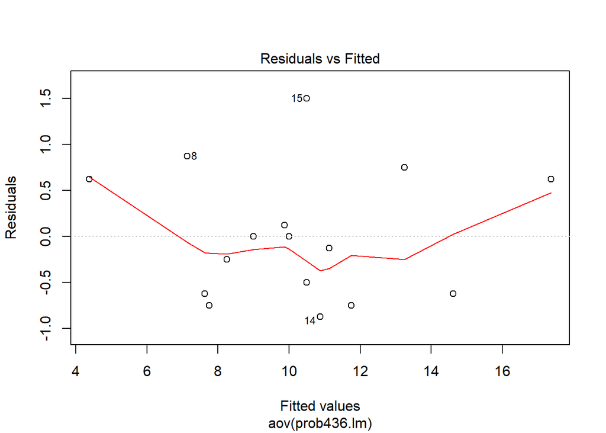

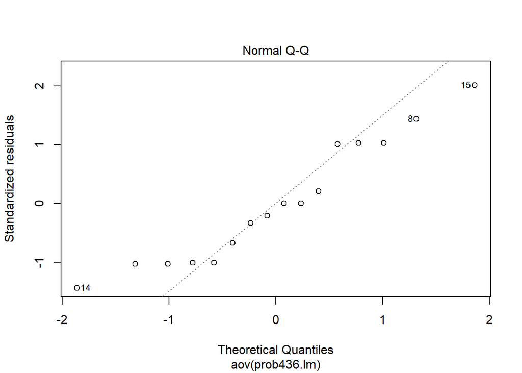

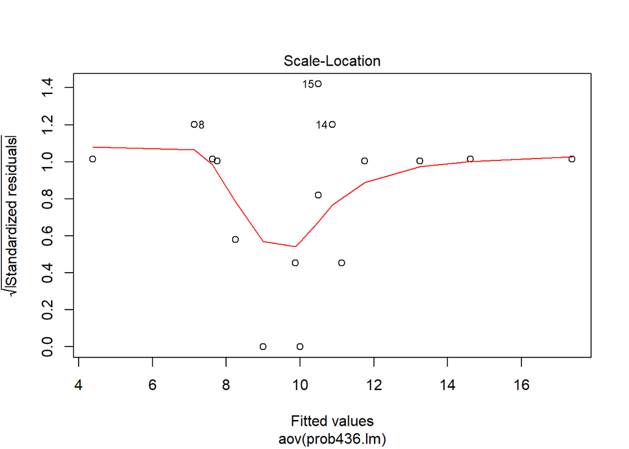

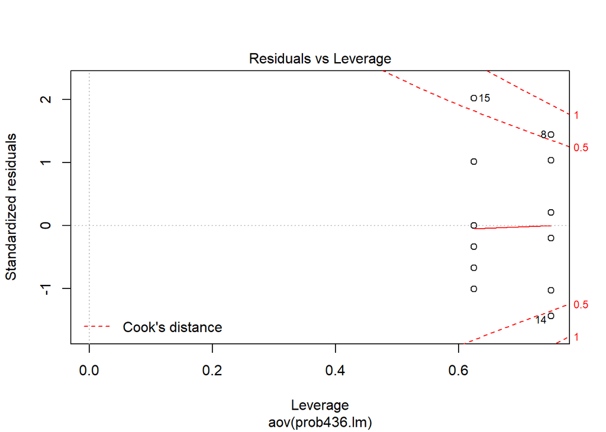

```r
plot(aov(prob436.lm))
```